# Practical Machine Learning : Course Project

jacethedatascientist

August 6, 2019

##### This document is the final project for the Coursera “Practical Machine Learning” course. It was produced using RStudio’s Markdown and Knitr.

## Overview

##### Using devices such as Jawbone Up, Nike FuelBand, and Fitbit, it is now possible to collect a large amount of data about personal activity relatively inexpensively. These type of devices are part of the quantified self movement – a group of enthusiasts who take measurements about themselves regularly to improve their health, to find patterns in their behavior, or because they are tech geeks. One thing that people regularly do is quantify how much of a particular activity they do, but they rarely quantify how well they do it.

##### In this project, your goal will be to use data from accelerometers on the belt, forearm, arm, and dumbell of 6 participants. They were asked to perform barbell lifts correctly and incorrectly in 5 different ways.

##### The data consists of a Training and a Test data (to be used to validate the selected model).

##### The goal of this project is to predict their exercise behavior. This is the *classe* variable in the training set. You may use any of the other variables to predict with.

##### **Note**: The dataset used in this project is courtesy of “Ugulino, W.; Cardador, D.; Vega, K.; Velloso, E.; Milidiu, R.; Fuks, H. Wearable Computing: Accelerometers’ Data Classification of Body Postures and Movements”

##### *Train Data*: https://d396qusza40orc.cloudfront.net/predmachlearn/pml-training.csv

##### *Test Data*: https://d396qusza40orc.cloudfront.net/predmachlearn/pml-testing.csv

##### *Additional Info*: http://web.archive.org/web/20161224072740/http:/groupware.les.inf.puc-rio.br/har

# Data and Library Reading

##### 1. Load the necessary libraries.

##### 2. Read the train and test datasets.

##### 3. Check the dimensions of each.

```r
library(caret)
```

```r
library(rpart)
library(rpart.plot)
library(RColorBrewer)
library(rattle)
library(randomForest)
library(corrplot)
library(gbm)
train1 <- read.csv('./pml-training.csv', header=T)
test1 <- read.csv('./pml-testing.csv', header=T)
dim(train1)
```

```
## [1] 19622   160
```

```r
dim(test1)
```

```
## [1]  20 160
```

# Data Pre-Processing

##### 1. Data cleaning (in this case, remove the incomplete columns).

##### 2. Remove the unnecessary columns (unique values, etc.).

```r
train2 <- train1[, colSums(is.na(train1)) == 0]
test2 <- test1[, colSums(is.na(test1)) == 0]
dim(train2)
```

```
## [1] 19622    93
```

```r
dim(test2)
```

```
## [1] 20 60
```

```r
train2 <- train2[-c(1:7)]
test2 <- test2[-c(1:7)]
```

# Data Splitting

##### 1. Split the data to obtain Train and Validate Set (75:25).

##### 2. Check the dimensions of each.

```r
set.seed(0000)
inTrain <- createDataPartition(train2$classe, p = 0.75, list = FALSE)
train3 <- train2[inTrain, ]
valid3 <- train2[-inTrain, ]
dim(train3)
```

```
## [1] 14718    86
```

```r
dim(valid3)
```

```
## [1] 4904   86
```

# Column Variability

##### 1. Use the *nearZeroVar* function to determine which columns have the least variance.

##### 2. Remove the columns with the least variance in the Train and Validation set.

##### 3. Check the dimensions of each.

```r
NZV <- nearZeroVar(train3)
train4 <- train3[, -NZV]
valid4  <- valid3[, -NZV]
dim(train4)
```

```
## [1] 14718    53
```

```r
dim(valid4)
```

```
## [1] 4904   53
```

# Predictor Correlation

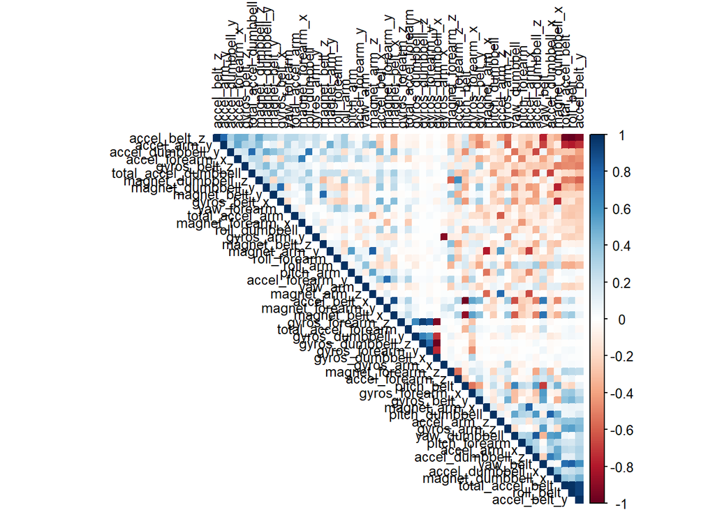

```r
corr_plot <- cor(train4[, -53])
corrplot(corr_plot, order = "FPC", method = "color", type = "upper",
         tl.cex = 0.8, tl.col = rgb(0, 0, 0))
```

```r
hCorr = findCorrelation(corr_plot, cutoff=0.80)
names(train4)[hCorr]
```

```
##  [1] "accel_belt_z"     "roll_belt"        "accel_belt_y"
##  [4] "accel_dumbbell_z" "accel_belt_x"     "pitch_belt"
##  [7] "accel_dumbbell_x" "accel_arm_x"      "magnet_arm_y"
## [10] "gyros_forearm_y"  "gyros_dumbbell_x" "gyros_dumbbell_z"
## [13] "gyros_arm_x"
```

# Modelling

##### 1. Random Forest

##### 2. Decision Trees

##### 3. Gradient Boosting Method

## **Random Forest**

###### Train the Random Forest Model

```r
TrCtrlRF <- trainControl(method="cv", number=10, verboseIter=FALSE)
modRF <- train(classe ~ ., data=train4, method="rf", trControl=TrCtrlRF)
modRF$finalModel
```

```
##
## Call:
##  randomForest(x = x, y = y, mtry = param$mtry)
##                Type of random forest: classification
##                      Number of trees: 500
## No. of variables tried at each split: 2
##
##         OOB estimate of  error rate: 0.57%
## Confusion matrix:
##      A    B    C    D    E class.error
## A 4180    4    0    0    1 0.001194743
## B   11 2833    4    0    0 0.005266854
## C    0   17 2549    1    0 0.007012076
## D    0    0   38 2372    2 0.016583748
## E    0    0    1    5 2700 0.002217295
```

###### Fit the RF model in the validation set

```r
predRF <- predict(modRF, newdata=valid4)
```

###### Plot the Confusion Matrix

```r
cmRF <- confusionMatrix(predRF, valid4$classe)
cmRF
```

```
## Confusion Matrix and Statistics
##
##           Reference
## Prediction    A    B    C    D    E
##          A 1394    6    0    0    0
##          B    0  943    9    0    0
##          C    0    0  846    9    0
##          D    0    0    0  795    4
##          E    1    0    0    0  897
##
## Overall Statistics
##
##                Accuracy : 0.9941
##                  95% CI : (0.9915, 0.996)
##     No Information Rate : 0.2845
##     P-Value [Acc > NIR] : < 2.2e-16
##
##                   Kappa : 0.9925
##
##  Mcnemar's Test P-Value : NA
##
## Statistics by Class:
##
##                      Class: A Class: B Class: C Class: D Class: E
## Sensitivity            0.9993   0.9937   0.9895   0.9888   0.9956
## Specificity            0.9983   0.9977   0.9978   0.9990   0.9998
## Pos Pred Value         0.9957   0.9905   0.9895   0.9950   0.9989
## Neg Pred Value         0.9997   0.9985   0.9978   0.9978   0.9990
## Prevalence             0.2845   0.1935   0.1743   0.1639   0.1837
## Detection Rate         0.2843   0.1923   0.1725   0.1621   0.1829
## Detection Prevalence   0.2855   0.1941   0.1743   0.1629   0.1831
## Balanced Accuracy      0.9988   0.9957   0.9936   0.9939   0.9977
```

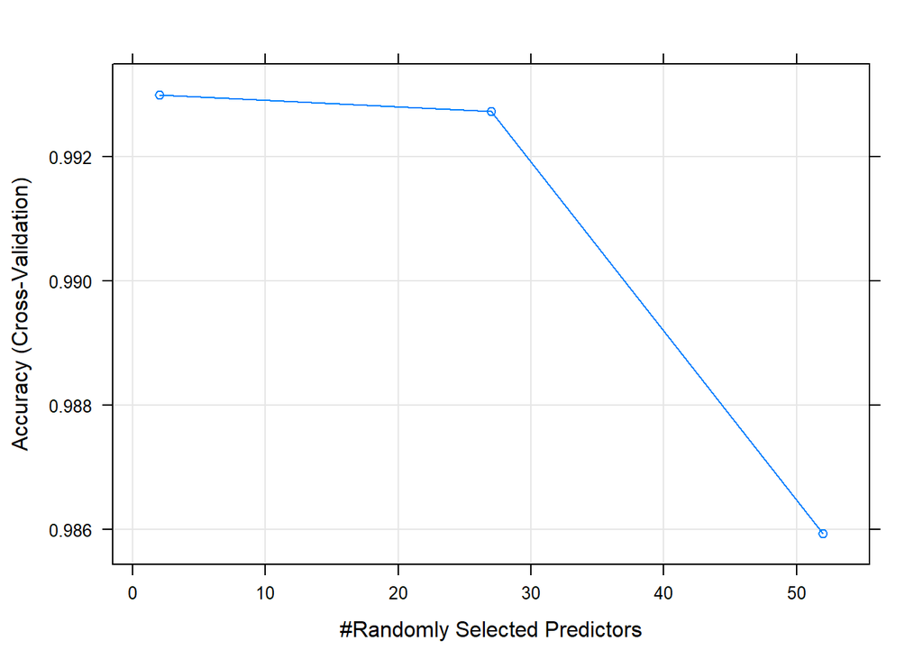

```r
plot(modRF)
```

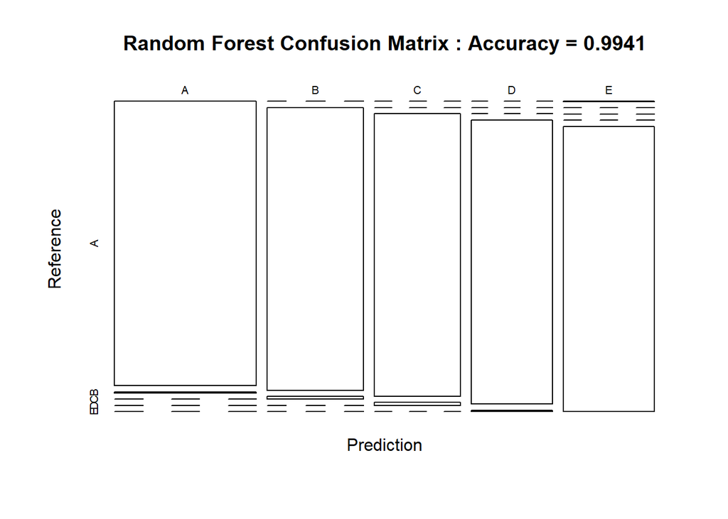

```r
plot(cmRF$table, col = cmRF$byClass,
     main = paste("Random Forest Confusion Matrix : Accuracy =",
                  round(cmRF$overall['Accuracy'], 4)))
```

## **Decision Trees**

###### Train the Decision Trees Model

```r
set.seed(0000)
modDT <- rpart(classe ~ ., data=train4, method="class")
```

###### Fit the Trees model in the validation set

```r
predDT <- predict(modDT, valid4, type = "class")
```

###### Plot the Confusion Matrix

```r
cmDT <- confusionMatrix(predDT, valid4$classe)
cmDT
```

```
## Confusion Matrix and Statistics
##
##           Reference
## Prediction    A    B    C    D    E
##          A 1247  144   21   55   18
##          B   37  533   49   53   50
##          C   46  133  673  105  108
##          D   44   66   59  527   47
##          E   21   73   53   64  678
##
## Overall Statistics
##
##                Accuracy : 0.7459
##                  95% CI : (0.7335, 0.7581)
##     No Information Rate : 0.2845
##     P-Value [Acc > NIR] : < 2.2e-16
##
##                   Kappa : 0.6781
##
##  Mcnemar's Test P-Value : < 2.2e-16
##
## Statistics by Class:
##
##                      Class: A Class: B Class: C Class: D Class: E
## Sensitivity            0.8939   0.5616   0.7871   0.6555   0.7525
## Specificity            0.9322   0.9522   0.9032   0.9473   0.9473
## Pos Pred Value         0.8397   0.7382   0.6319   0.7093   0.7627
## Neg Pred Value         0.9567   0.9005   0.9526   0.9334   0.9445
## Prevalence             0.2845   0.1935   0.1743   0.1639   0.1837
## Detection Rate         0.2543   0.1087   0.1372   0.1075   0.1383
## Detection Prevalence   0.3028   0.1472   0.2172   0.1515   0.1813
## Balanced Accuracy      0.9130   0.7569   0.8452   0.8014   0.8499
```

[figure not shown]

```r
fancyRpartPlot(modDT)
```

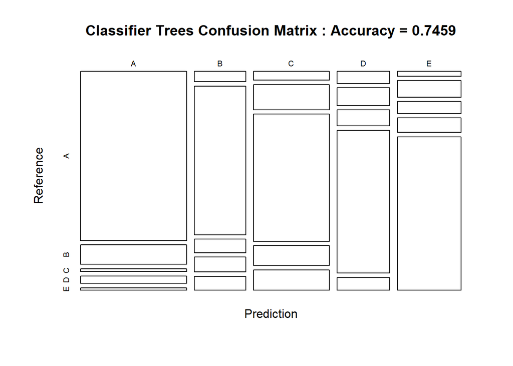

```r
plot(cmDT$table, col = cmDT$byClass,
     main = paste("Classifier Trees Confusion Matrix : Accuracy =",
                  round(cmDT$overall['Accuracy'], 4)))
```

### The accuracy rate using the decision tree is much lower, Accuracy is 0.7459, therefore the *out-of-sample-error is equal to 0.2541*.

## **Gradient Boosting Method**

###### Train the GBM Model

```r
set.seed(0000)
TrCtrlGBM <- trainControl(method = "repeatedcv", number = 10, repeats = 5)
modGBM  <- train(classe ~ ., data=train4, method = "gbm",
                 trControl = TrCtrlGBM, verbose = FALSE)
modGBM$finalModel
```

```
## A gradient boosted model with multinomial loss function.
## 150 iterations were performed.
## There were 52 predictors of which 52 had non-zero influence.
```

```r
print(modGBM)
```

```
## Stochastic Gradient Boosting
##
## 14718 samples
##    52 predictor
##     5 classes: 'A', 'B', 'C', 'D', 'E'
##
## No pre-processing
## Resampling: Cross-Validated (10 fold, repeated 5 times)
## Summary of sample sizes: 13246, 13246, 13246, 13248, 13246, 13247, ...
## Resampling results across tuning parameters:
##
##   interaction.depth  n.trees  Accuracy   Kappa
##   1                   50      0.7539470  0.6879820
##   1                  100      0.8223530  0.7750942
##   1                  150      0.8546121  0.8159901
##   2                   50      0.8545715  0.8157030
##   2                  100      0.9068208  0.8820738
##   2                  150      0.9318516  0.9137613
##   3                   50      0.8955826  0.8678076
##   3                  100      0.9420703  0.9267015
##   3                  150      0.9619924  0.9519156
##
## Tuning parameter 'shrinkage' was held constant at a value of 0.1
##
## Tuning parameter 'n.minobsinnode' was held constant at a value of 10
## Accuracy was used to select the optimal model using the largest value.
## The final values used for the model were n.trees = 150,
##  interaction.depth = 3, shrinkage = 0.1 and n.minobsinnode = 10.
```

###### Fit the GBM model in the validation set

```r
predGBM <- predict(modGBM, newdata=valid4)
```

###### Plot the Confusion Matrix

```r
cmGBM <- confusionMatrix(predGBM, valid4$classe)
cmGBM
```

```
## Confusion Matrix and Statistics
##
##           Reference
## Prediction    A    B    C    D    E
##          A 1371   28    0    1    2
##          B   13  903   21    2   10
##          C    4   15  814   25    5
##          D    0    2   19  774   12
##          E    7    1    1    2  872
##
## Overall Statistics
##
##                Accuracy : 0.9653
##                  95% CI : (0.9598, 0.9703)
##     No Information Rate : 0.2845
##     P-Value [Acc > NIR] : < 2.2e-16
##
##                   Kappa : 0.9561
##
##  Mcnemar's Test P-Value : 0.0003628
##
## Statistics by Class:
##
##                      Class: A Class: B Class: C Class: D Class: E
## Sensitivity            0.9828   0.9515   0.9520   0.9627   0.9678
## Specificity            0.9912   0.9884   0.9879   0.9920   0.9973
## Pos Pred Value         0.9779   0.9515   0.9432   0.9591   0.9875
## Neg Pred Value         0.9931   0.9884   0.9899   0.9927   0.9928
## Prevalence             0.2845   0.1935   0.1743   0.1639   0.1837
## Detection Rate         0.2796   0.1841   0.1660   0.1578   0.1778
## Detection Prevalence   0.2859   0.1935   0.1760   0.1646   0.1801
## Balanced Accuracy      0.9870   0.9699   0.9700   0.9773   0.9825
```

### The accuracy rate using the GBM is a little lower, Accuracy is 0.9653, therefore the *out-of-sample-error is equal to 0.0347*.

# Testing the Model

##### 1. Use the Random Forest Model as it has the most accurate prediction.

##### 2. Fit the RF Model in the Test Set.

##### 3. Print values.

```r
TestPred <- predict(modRF, newdata=test2)
TestPred
```

```
##  [1] B A B A A E D B A A B C B A E E A B B B
## Levels: A B C D E
```

###### *The resulting values will then be the answer to the **Course Project Prediction Quiz***

#### ===================================================================================

#### *This formally ends the Course Project. Thank You!*